# Outlier and Venn Diagram Results from Pinus contorta at different cutoffs

Katie Lotterhos

April 16, 2015

In this analysis, we ran bayenv2 (Gunther and Coop 2013) on over 1,000,000 SNPs from the Pine sequence capture. We had 22 environmental variables of biological interest.

### The environmental variables used in this study

We performed a hierarchical cluster analysis on the 22 environmental variables as a way to summarize the outliers and account for correlated variables.

```r
env <- read.table("sprucePineEnvi.clusters", header=TRUE)
env
```

```
##      enviAbb                   enviDesc G3 G4
## 1        LAT                   Latitude  1  0
## 2       LONG                  Longitude  2  0
## 3  ELEVATION                  Elevation  3  0
## 4        MAT             Mean ann. temp  1  1
## 5       MWMT         Mean warmest month  3  3
## 6       MCMT         Mean coldest month  1  1
## 7         TD            Temp difference  1  1
## 8        MAP  Mean annual precipitation  2  2
## 9        MSP  Mean summer precipitation  2  2
## 10       AHM Anuual heat:moisture index  2  2
## 11       SHM Summer heat:moisture index  2  2
## 12      DD_0                  Days < 0C  1  1
## 13       DD5                  Days > 5C  3  3
## 14      NFFD          # frost-free days  3  3
## 15      bFFP    Begin frost-free period  3  3
## 16      eFFP      End frost-free period  3  3
## 17       FFP          Frost-free period  3  3
## 18       PAS      Precipitation as snow  2  2
## 19       EMT Extreme min. temp 30 years  1  1
## 20       EXT Extreme max. temp 30 years  2  2
## 21      Eref                Evaporation  2  2
## 22       CMD   Climate moisture deficit  2  2
```

In the table above, column G3 represents the group from the hierarchical clustering. For analysis, we took out Latitude, Longitude, and Elevation and analyzed them separately because they do not represent environments per se but rather variables that correlate with other selective pressures that we didn’t measure (for example elevation may correlate with UV exposure). So column G4 was used for analysis.

An image of the clustered environments for pine:

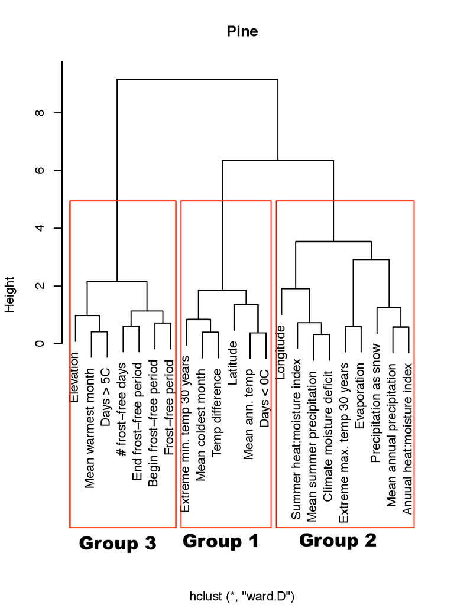

The environments cluster into three groups. Group 1 contains variables that correlate with mean annual temperature, Group 2 contains variables that correlate with mean annual precipitation, and Group 3 contains variables that correlate with frost-free period.

### The SNP dataset

Here are the column names in the SNP dataset: (the ones named after the environments contain Bayes Factors. “rho” represents Spearman’s rho, which indicates the correlation between the reference SNP frequency and the environment.)

```r
filename <- "var_out_GATK3_allhet_pine688_ALL.summary.ALL.annots.sorted.GOOD.window.3xbf.log10"
### read in file with log-BF
  if(!("f2" %in% ls())){
    f2<- read.table(filename, header=TRUE, comment.char="")
  }
  names(f2)
```

```
##  [1] "X.annotation"     "paralogy_rank"    "tcontig"
##  [4] "pos_tcontig"      "gmap_percentID"   "offtarget_dist"
##  [7] "gcontig"          "pos_gcontig"      "num_alleles"
## [10] "num_ind"          "num_comm_gtype"   "major_allele"
## [13] "major_num"        "major_freq"       "minor_allele"
## [16] "minor_num"        "minor_freq"       "freq_hetzyg"
## [19] "MAP_dir1"         "MAP_dir2"         "MAP_MgGm"
## [22] "noncode_in_covar" "MQ"               "haplotype_score"
## [25] "FS"               "MQRankSum"        "ReadPosRankSum"
## [28] "allele_balance"   "window_stat"      "scaffold"
## [31] "scaf_pos"         "xtx"              "LAT"
## [34] "LAT_rho1"         "LAT_rho2"         "LONG"
## [37] "LONG_rho1"        "LONG_rho2"        "ELEVATION"
## [40] "ELEVATION_rho1"   "ELEVATION_rho2"   "MAT"
## [43] "MAT_rho1"         "MAT_rho2"         "MWMT"
```

[output cut: 18 more lines]

The total number of SNPs used for analysis:

```r
nrow(f2)
```

```
## [1] 1251059
```

The Bayes factors from all environments were pooled to calculate cutoffs for the 0.9999, 0.999, 0.99 and 0.95 quartiles of the BF distribution. Here are the BF cutoffs for those percentiles:

```r
### read in file with cutoffs
  cos <- read.table(paste(filename,".cutoffs", sep=""), header=TRUE)
  cos
```

```
##     V.9999    V.999      V.99       V.95    max.V
## 1 4.122732 1.729643 0.4776416 -0.1456555 29.77007
```

Now loop through each of these cutoffs (except for max) and summarize the results:

### Results for V.9999 percentile, which corresponds outliers with a BF > 4.123

**The number of outliers in each environmental variable with BF > 4.123**

|  | numOutliers |
| --- | --- |
| LAT | 135.00 |
| LONG | 120.00 |
| ELEVATION | 9.00 |
| MAT | 126.00 |
| MWMT | 10.00 |
| MCMT | 161.00 |
| TD | 112.00 |
| MAP | 33.00 |
| MSP | 96.00 |
| AHM | 215.00 |
| SHM | 82.00 |
| DD_0 | 137.00 |
| DD5 | 52.00 |
| NFFD | 127.00 |
| bFFP | 17.00 |
| eFFP | 135.00 |
| FFP | 62.00 |
| PAS | 1.00 |
| EMT | 235.00 |
| EXT | 84.00 |
| Eref | 157.00 |
| CMD | 309.00 |

- **Number of latitude outliers:** 135
- **Number of longitude outliers:** 120
- **Number of elevation outliers:** 9

**Number of outliers in each group** (loci with an outlier an any one environment in group 1)

- **Group 1** (temperature): 299
- **Group 2** (precipitation): 427
- **Group 3** (frost-free period): 159

**Number of outliers in each group SCALED by the number of environmental variables in that group**

- Scaled Group 1 (temperature): 59.8
- Scaled Group 2 (precipitation): 53.4
- Scaled Group 3 (frost-free period): 26.5

#### Total number of outliers (loci with BF above threshold in any one environment): 838

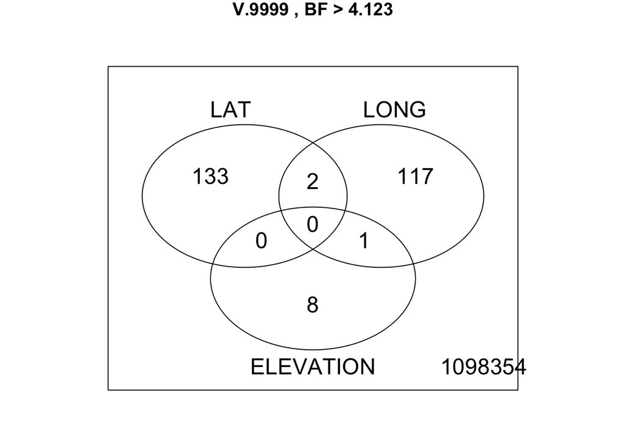

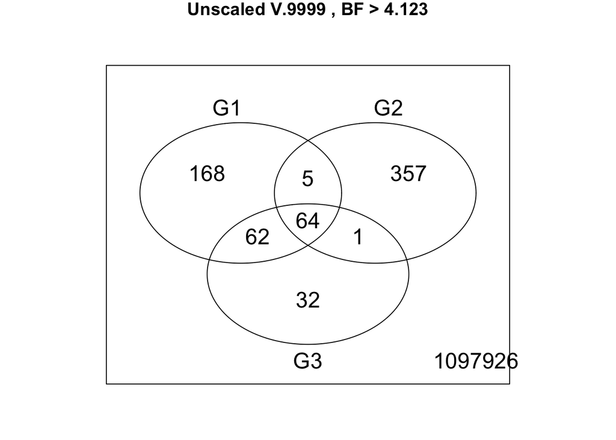

### Results for V.999 percentile, which corresponds outliers with a BF > 1.73

**The number of outliers in each environmental variable with BF > 1.73**

|  | numOutliers |
| --- | --- |
| LAT | 1900.00 |
| LONG | 3631.00 |
| ELEVATION | 797.00 |
| MAT | 897.00 |
| MWMT | 329.00 |
| MCMT | 1582.00 |
| TD | 1602.00 |
| MAP | 592.00 |
| MSP | 893.00 |
| AHM | 923.00 |
| SHM | 1014.00 |
| DD_0 | 1360.00 |
| DD5 | 439.00 |
| NFFD | 1044.00 |
| bFFP | 409.00 |
| eFFP | 996.00 |
| FFP | 651.00 |
| PAS | 275.00 |
| EMT | 1728.00 |
| EXT | 820.00 |
| Eref | 1096.00 |
| CMD | 1172.00 |

- **Number of latitude outliers:** 1900
- **Number of longitude outliers:** 3631
- **Number of elevation outliers:** 797

**Number of outliers in each group** (loci with an outlier an any one environment in group 1)

- **Group 1** (temperature): 3662
- **Group 2** (precipitation): 3224
- **Group 3** (frost-free period): 1916

**Number of outliers in each group SCALED by the number of environmental variables in that group**

- Scaled Group 1 (temperature): 732.4
- Scaled Group 2 (precipitation): 403
- Scaled Group 3 (frost-free period): 319.3

#### Total number of outliers (loci with BF above threshold in any one environment): 12323

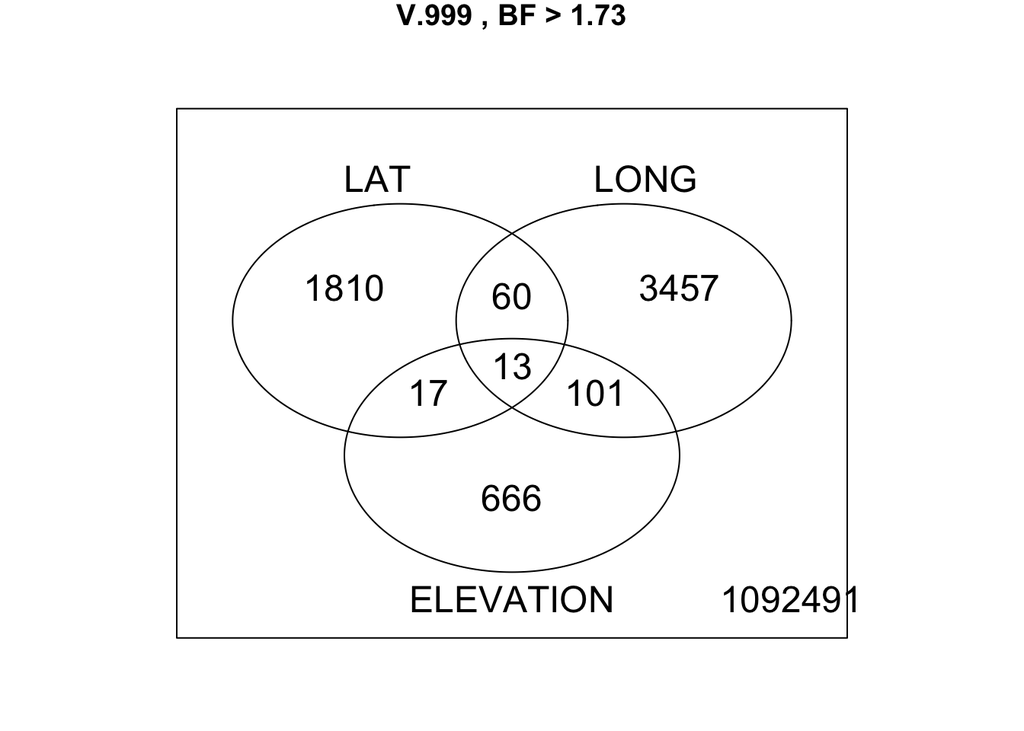

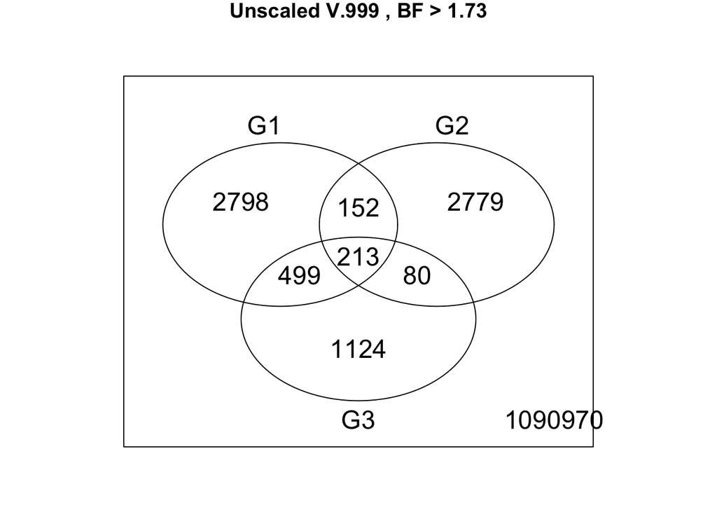

### Results for V.99 percentile, which corresponds outliers with a BF > 0.478

**The number of outliers in each environmental variable with BF > 0.478**

|  | numOutliers |
| --- | --- |
| LAT | 16828.00 |
| LONG | 34769.00 |
| ELEVATION | 12136.00 |
| MAT | 10270.00 |
| MWMT | 5953.00 |
| MCMT | 13795.00 |
| TD | 13725.00 |
| MAP | 8339.00 |
| MSP | 7415.00 |
| AHM | 6679.00 |
| SHM | 10822.00 |
| DD_0 | 12486.00 |
| DD5 | 7081.00 |
| NFFD | 10283.00 |
| bFFP | 7277.00 |
| eFFP | 10532.00 |
| FFP | 8401.00 |
| PAS | 5930.00 |
| EMT | 14322.00 |
| EXT | 7165.00 |
| Eref | 9208.00 |
| CMD | 8087.00 |

- **Number of latitude outliers:** 16828
- **Number of longitude outliers:** 34769
- **Number of elevation outliers:** 12136

**Number of outliers in each group** (loci with an outlier an any one environment in group 1)

- **Group 1** (temperature): 34144
- **Group 2** (precipitation): 42287
- **Group 3** (frost-free period): 25117

**Number of outliers in each group SCALED by the number of environmental variables in that group**

- Scaled Group 1 (temperature): 6828.8
- Scaled Group 2 (precipitation): 5285.9
- Scaled Group 3 (frost-free period): 4186.2

#### Total number of outliers (loci with BF above threshold in any one environment): 129349

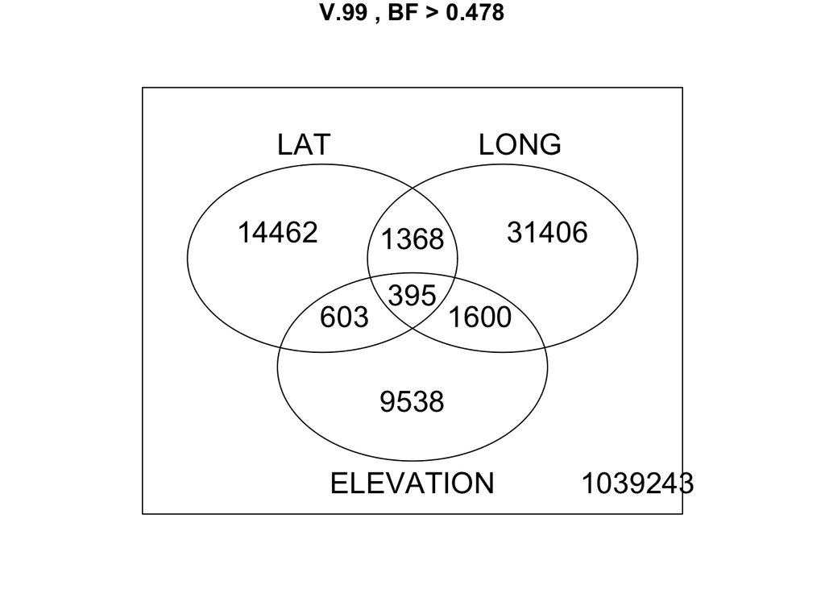

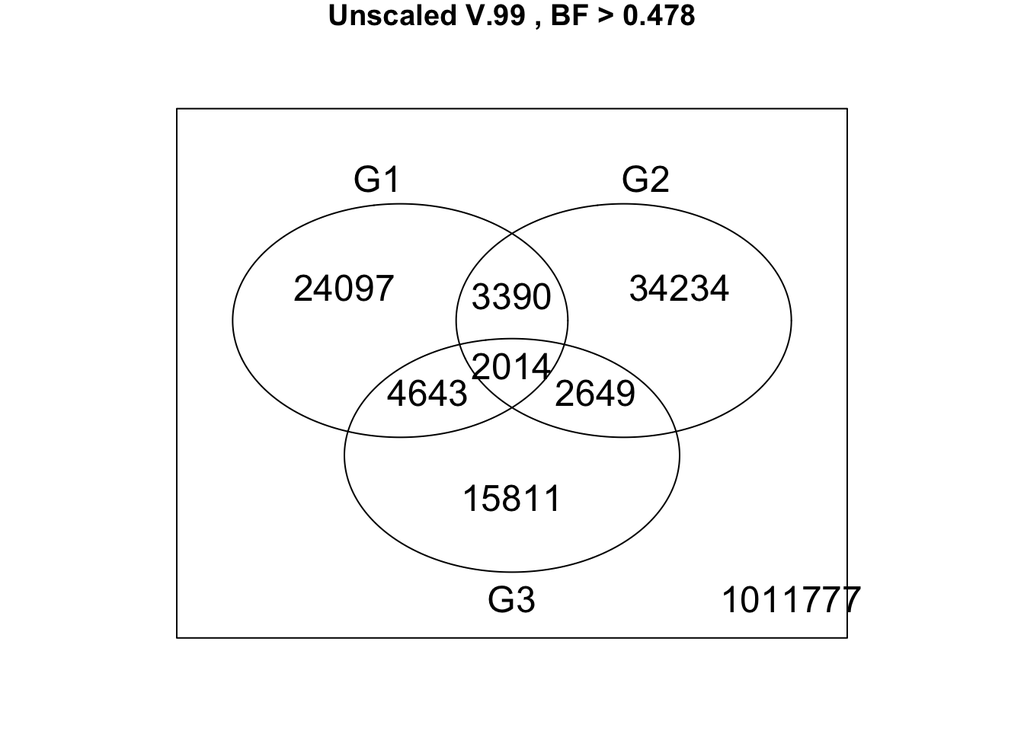

### Results for V.95 percentile, which corresponds outliers with a BF > -0.146

**The number of outliers in each environmental variable with BF > -0.146**

|  | numOutliers |
| --- | --- |
| LAT | 75723.00 |
| LONG | 144913.00 |
| ELEVATION | 65382.00 |
| MAT | 52304.00 |
| MWMT | 36036.00 |
| MCMT | 61818.00 |
| TD | 59703.00 |
| MAP | 43647.00 |
| MSP | 38270.00 |
| AHM | 34321.00 |
| SHM | 68691.00 |
| DD_0 | 57047.00 |
| DD5 | 43146.00 |
| NFFD | 53626.00 |
| bFFP | 40967.00 |
| eFFP | 54200.00 |
| FFP | 45990.00 |
| PAS | 34971.00 |
| EMT | 66449.00 |
| EXT | 39293.00 |
| Eref | 51504.00 |
| CMD | 41708.00 |

- **Number of latitude outliers:** 75723
- **Number of longitude outliers:** 144913
- **Number of elevation outliers:** 65382

**Number of outliers in each group** (loci with an outlier an any one environment in group 1)

- **Group 1** (temperature): 144632
- **Group 2** (precipitation): 211125
- **Group 3** (frost-free period): 123190

**Number of outliers in each group SCALED by the number of environmental variables in that group**

- Scaled Group 1 (temperature): 28926.4
- Scaled Group 2 (precipitation): 26390.6
- Scaled Group 3 (frost-free period): 20531.7

#### Total number of outliers (loci with BF above threshold in any one environment): 486939

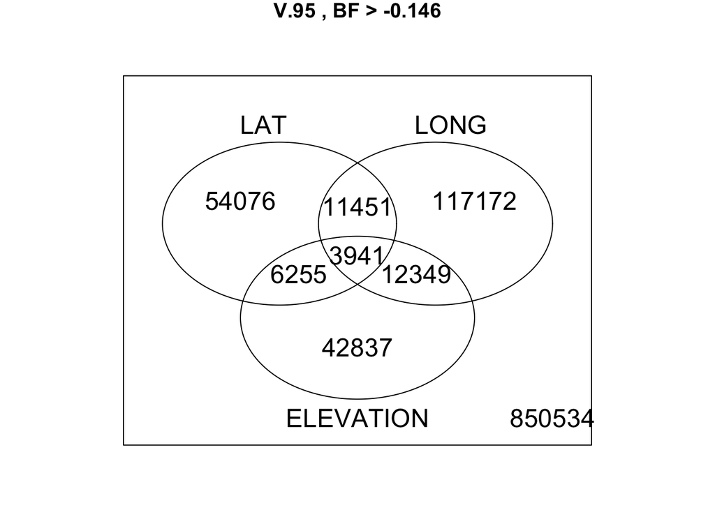

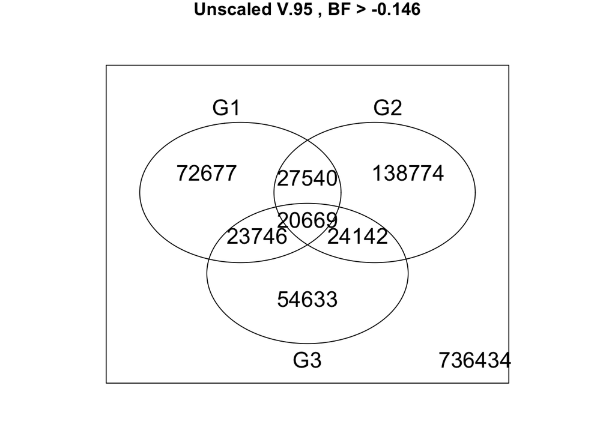